Bitcoin Price Model Analysis - Final Project

Md Zinnun Uddin

# 1 Objective of the Project

The main purpose of this project is to implement the acquired knowledge in a real-life situation using Regression & Time Series analysis in detail. In this project, I will perform Regression & Time Series analysis and forecasting techniques on Bitcoin historical price.

# 2 Dataset

Dataset of Bitcoin (BTC) historical price against USD is a monthly average price dataset having prices from 01 January 2015 to 30 November 2023.

# 3 Applied Models

Below models are applied in this project:

- Linear regression model
- Quadratic regression model
- ARIMA model

# 4 Task to Perform

## 4.1 Loading the dataset & necessary libraries:

The dataset is loaded and checked for data types and missing values. The dataset was found to have no missing values.

```r
# Load necessary libraries
library(tidyverse)
library(lubridate)
library(forecast)
library(tseries)
library(kableExtra)
library(dplyr)
library(ggplot2)
```

```r
## Load the dataset
BitCoin <- read.csv("E:\\MSc-DADT\\Statistics\\BTC--Monthly.csv")
```

```r
# Check the data types of the features
str(BitCoin)
'data.frame':   107 obs. of  2 variables:
 $ Date : chr  "1/1/2015" "2/1/2015" "3/1/2015" "4/1/2015" ...
 $ Close: num  217 254 244 236 230 ...

# Assign appropriate data type to features
BitCoin$Date <- as.Date(BitCoin$Date, format = "%m/%d/%Y")
names(BitCoin)[names(BitCoin) == "Close"] <- "Price"

# Check the structure of the data frame
str(BitCoin)
'data.frame':   107 obs. of  2 variables:
 $ Date : Date, format: "2015-01-01" "2015-02-01" ...
 $ Price: num  217 254 244 236 230 ...

# Check if there’s any missing value
sum(is.na(BitCoin))
[1] 0
```

The code checks the structure of the `BitCoin` data frame, converts the `Date` column to the `Date` type, renames the `Close` column to `Price`, and then verifies the changes. There are no missing values found.

## 4.2 Descriptive Analytics:

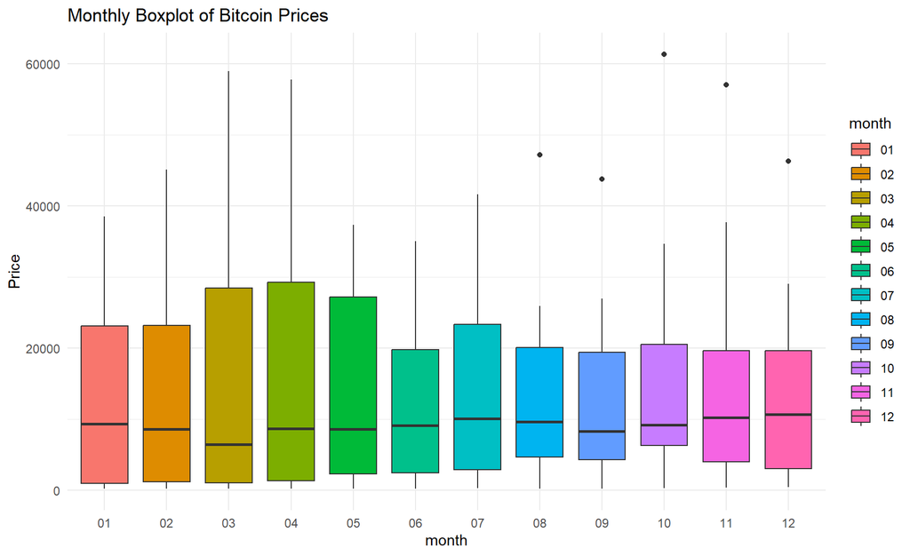

```r
# Copy the BitCoin data frame to a new data frame named BitCoin_df
BitCoin_df <- BitCoin

# Create two more columns 'month' & 'year' by populating with the months & years values from the 'Date' column
BitCoin_df$month <- format(BitCoin_df$Date, "%m")
BitCoin_df$year <- format(BitCoin_df$Date, "%Y")

# Create a monthly boxplot of prices

ggplot(BitCoin_df, aes(x = month, y = Price, fill = month)) +
  geom_boxplot() +
  theme_minimal() +
  ggtitle("Monthly Boxplot of Bitcoin Prices")
```

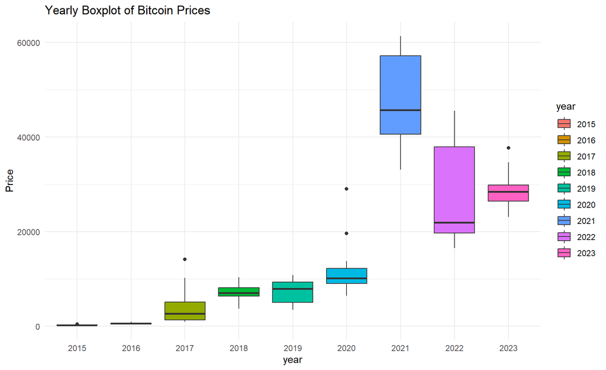

```r
# Create a yearly boxplot of prices
ggplot(BitCoin_df, aes(x = year, y = Price, fill = year)) +
  geom_boxplot() +
  theme_minimal() +
  ggtitle("Yearly Boxplot of Bitcoin Prices")
```

**Yearly Boxplot of Bitcoin Prices:** The yearly boxplot shows the lowest bitcoin prices with minimal fluctuation in the year 2015-2016. 2017-2019 shows a gradual increase in prices with some fluctuations over the months. 2020 is interesting because although the median shows gradual increase but a few points are way above the 75th percentile, indicating he start of high fluctuations. 2021 is the peak with a gradual decline in 2022.

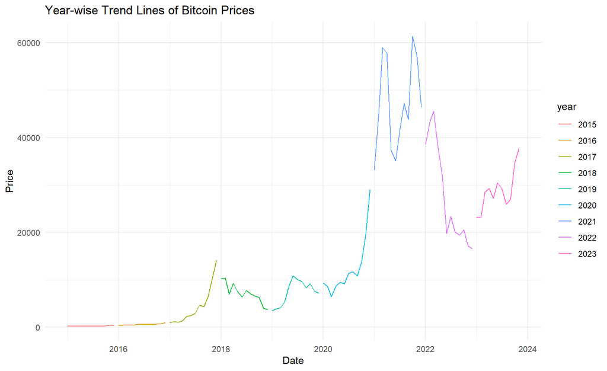

```r
# Create year wise trend lines of prices
ggplot(BitCoin_df, aes(x = Date, y = Price, color = year)) +
  geom_line() +
  theme_minimal() +
  ggtitle("Year-wise Trend Lines of Bitcoin Prices")
```

**Year-wise Trend Lines of Bitcoin Prices:** This plot provides a visual representation of the price trends over time. It helps in identifying overall growth patterns, significant peaks, and drops. Once again, the years 2020-to 2022 show great fluctuations and the peak of bitcoin prices.

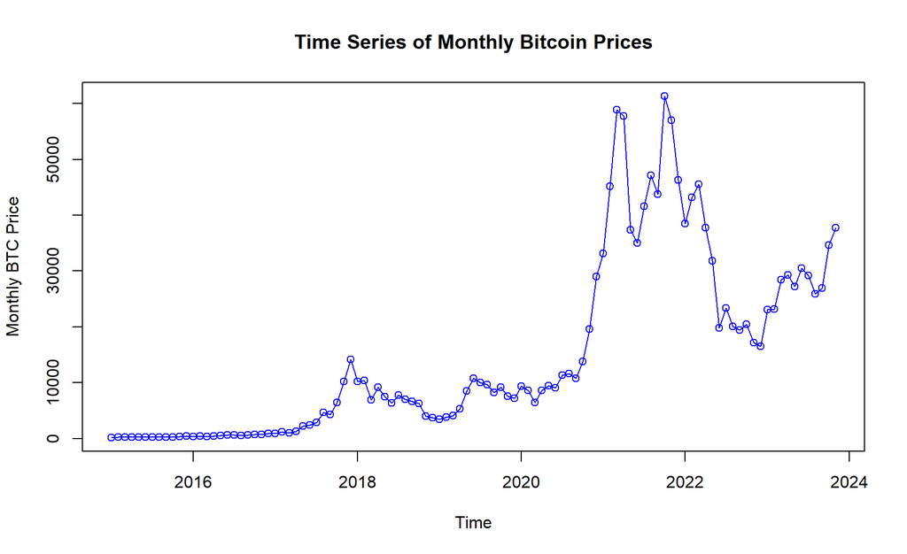

```r
# Convert the BitCoin data frame to a time series object with frequency 1
btc_ts <- ts(BitCoin$Price, start = c(2015, 1), frequency = 12)

# Plot the time series of monthly prices on years
plot(btc_ts, ylab = "Monthly BTC Price", xlab = "Time", type = "o", col = "blue", main = "Time Series of Monthly Bitcoin Prices")
```

**Time series of Monthly Bitcoin Prices:** The time series clearly shows an upward trend and slight seasonality from the end of the year 2000.

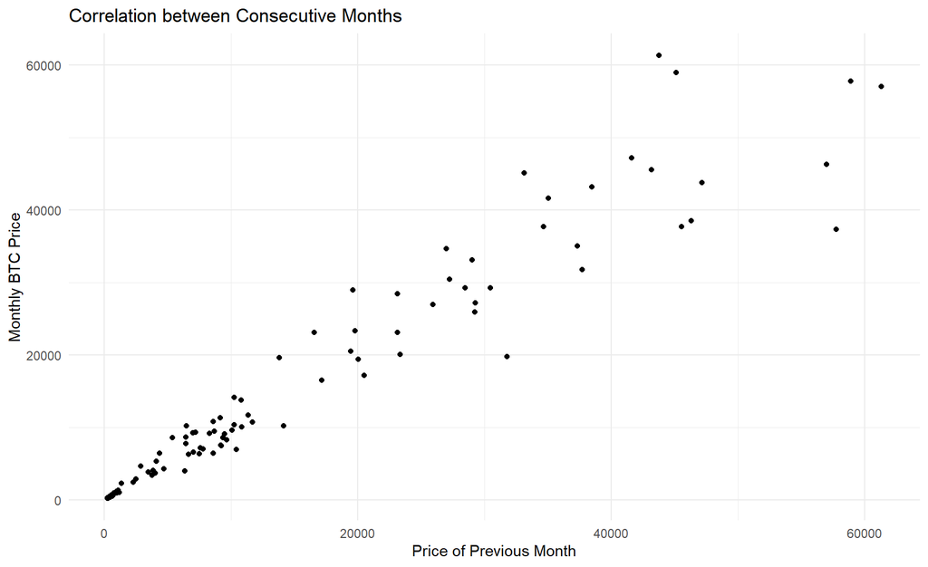

```r
# Find the relationship between consecutive months. Show the correlation through a scatter plot
cor(BitCoin_df$Price[-1], BitCoin_df$Price[-nrow(BitCoin_df)])
[1] 0.9617764
ggplot(BitCoin_df[-1,], xlab="Price of previous month", ylab="Monthly BTC price", aes(x = BitCoin_df$Price[-nrow(BitCoin_df)], y = Price)) +
  geom_point() +
  labs(x = "Price of Previous Month", y = "Monthly BTC Price") +
  theme_minimal() +
  ggtitle("Correlation between Consecutive Months")
```

**Correlation between Consecutive Months** A high correlation (0.9618) between consecutive months suggests that Bitcoin prices are highly dependent on the prices in the previous month, indicating a strong autocorrelation in the data.

## 4.3 Regression Analysis

### 4.3.1 Linear Regression

```r
# Create a linear model of the time series dataset
linear_model <- lm(Price ~ Date, data = BitCoin_df)

# Show the summary of the model and explain the outcome
summary(linear_model)

Call:
lm(formula = Price ~ Date, data = BitCoin_df)

Residuals:
   Min     1Q Median     3Q    Max
-15114  -7997  -2255   3065  35626

Coefficients:
              Estimate Std. Error t value Pr(>|t|)
(Intercept) -2.211e+05  1.939e+04  -11.40   <2e-16 ***
Date         1.308e+01  1.073e+00   12.19   <2e-16 ***
---
Signif. codes:  0 '***' 0.001 '**' 0.01 '*' 0.05 '.' 0.1 ' ' 1

Residual standard error: 10430 on 105 degrees of freedom
Multiple R-squared:  0.586, Adjusted R-squared:  0.5821
F-statistic: 148.6 on 1 and 105 DF,  p-value: < 2.2e-16
```

#### Regression Analysis

- *Model Summary:*
  - R2 : 0.586.
  - Adjusted R2 : 0.5821.
  - The model explains approximately 58.6% of the variance in Bitcoin prices.While this is a substantial proportion, there is still a significant amount of variance that is not explained by the model.
  - The p-value for the Date coefficient is < 2e-16, indicating a significant relationship.

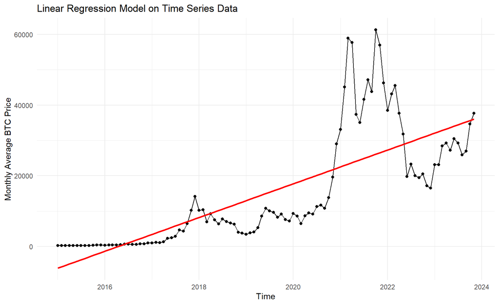

```r
# Create a plot of the linear model on top of the time series dataset line plot with scatter data points
ggplot(BitCoin_df, aes(x = Date, y = Price)) +
  geom_point() +
  geom_line() +
  geom_smooth(method = "lm", se = FALSE, color = "red") +
  labs(x = "Time", y = "Monthly Average BTC Price") +
  theme_minimal() +
  ggtitle("Linear Regression Model on Time Series Data")
```

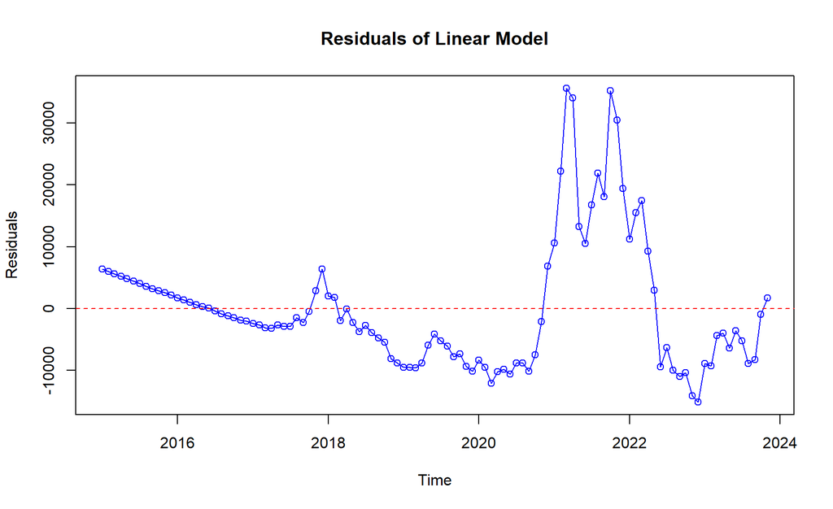

```r
# Perform residual analysis and create a line & scatter plot of the residuals. Explain the outcome
residuals <- resid(linear_model)
plot(BitCoin_df$Date, residuals,xlab="Time", ylab="Residuals", type = "o", col = "blue", main = "Residuals of Linear Model")
abline(h=0.05, col= "red",lty=2)
```

#### Residual Analysis:

- **Pattern in Residuals:** The residual plot shows patterns, suggesting non-linearity and autocorrelation. Ideally, residuals should be randomly scattered around zero without any discernible pattern.

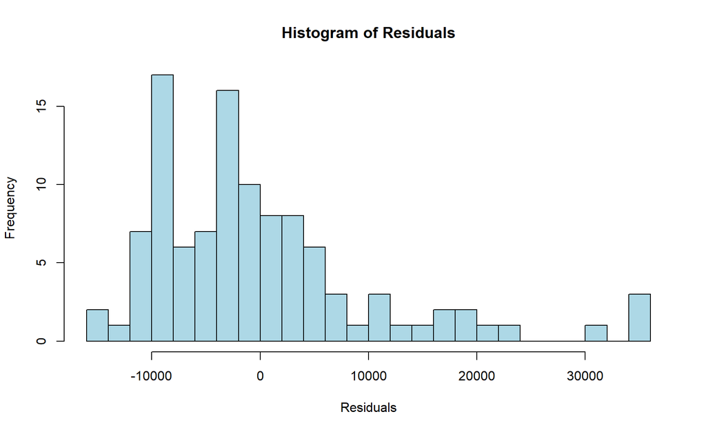

```r
# Create a histogram plot of the residuals. Explain the outcome
hist(residuals, xlab="Residuals", breaks = 30, col = "lightblue", main = "Histogram of Residuals")
```

**Histogram of Residuals:** The histogram indicated that the residuals are not normally distributed and do not follow a bell shaped with the peak at zero. Normality of residuals is an assumption of linear regression. We can see from the histogram that there is skewness on the right hand side. And maximum residual exists majorly on the left hand side of the histogram.

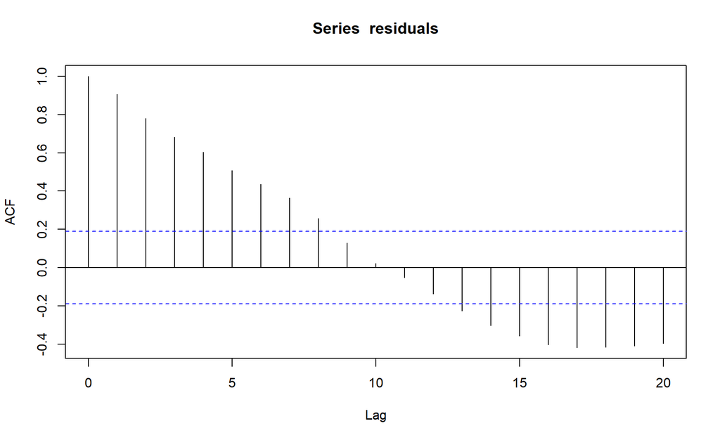

```r
# Create ACF & PACF plots of residuals. Explain the outcome
acf(residuals)
```

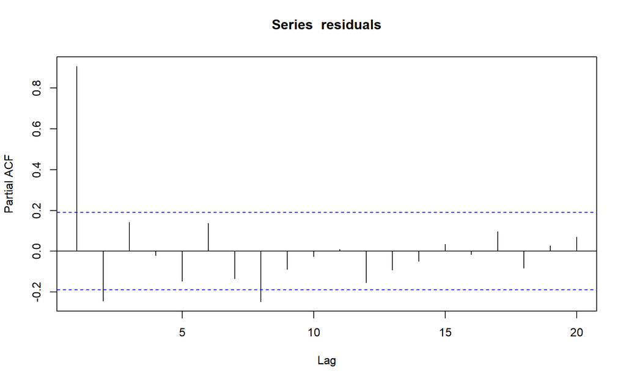

```r
pacf(residuals)
```

**ACF and PACF of Residuals:** The ACF and PACF plots shows significant autocorrelation in the residuals. This can be seen from the gradual decrease in the ACF plot, indicating that the residuals are not independent. This suggests that the model has not adequately captured all the underlying patterns and dependencies in the data.

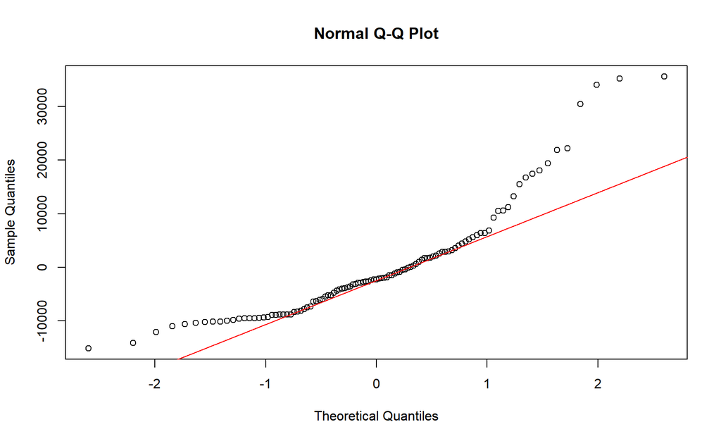

```r
# Create QQ plot of residuals. Explain the outcome
qqnorm(residuals)
qqline(residuals, col = "red")
```

**QQ Plot:** The QQ plot showed that the residuals deviate from the line, suggesting that they are not normally distributed.

```r
# Perform Shapiro-Wilk test on residuals. Explain the outcome
shapiro.test(residuals)

    Shapiro-Wilk normality test

data:  residuals
W = 0.85983, p-value = 1.215e-08
```

**Shapiro-Wilk Test:** The Shapiro-Wilk test returned a p-value of 1.215e-08, confirming that the residuals are not normally distributed.

**Model Appropriateness:** While the linear regression model indicates a statistically significant relationship between Date and Bitcoin Price, several assumptions of linear regression are violated:

- The residuals are not normally distributed.
- There is significant autocorrelation in the residuals.
- The residuals show patterns indicating non-linearity.

Given these violations, the linear regression model may not be the most appropriate for accurately modeling and forecasting Bitcoin prices.

### 4.3.2 Quadratic Regression

```r
# Create a quadratic model of the time series dataset
BitCoin_df$Date <- as.numeric(BitCoin_df$Date)
quadratic_model <- lm(Price ~ poly(Date, 2), data = BitCoin_df)

# Show the summary of the model and explain the outcome
summary(quadratic_model)

Call:
lm(formula = Price ~ poly(Date, 2), data = BitCoin_df)

Residuals:
   Min     1Q Median     3Q    Max
-15872  -7420  -1996   2666  36106

Coefficients:
               Estimate Std. Error t value Pr(>|t|)
(Intercept)       14944       1010  14.794   <2e-16 ***
poly(Date, 2)1   127161      10449  12.170   <2e-16 ***
poly(Date, 2)2     8246      10449   0.789    0.432
---
Signif. codes:  0 '***' 0.001 '**' 0.01 '*' 0.05 '.' 0.1 ' ' 1

Residual standard error: 10450 on 104 degrees of freedom
Multiple R-squared:  0.5885,    Adjusted R-squared:  0.5806
F-statistic: 74.36 on 2 and 104 DF,  p-value: < 2.2e-16
```

#### Quadratic Regression

- *Model Summary:*
  - 𝑅2 : 0.5885.
  - Adjusted R2 : 0.5806.
  - Similar𝑅2 to the linear model but includes a non-significant quadratic term.

**Model Appropriateness:**

The quadratic term is not significant (p-value = 0.432), Suggesting that the quadratic model does not significantly improve the fit compared to the linear model. Based on the model summary and the characteristics of Bitcoin price data,the non-significance of the quadratic term and the moderate R-squared value suggest that this model does not capture the complexity of the data adequately.

## 4.4 ARIMA Model

### Testing The Data Set for Stationarity

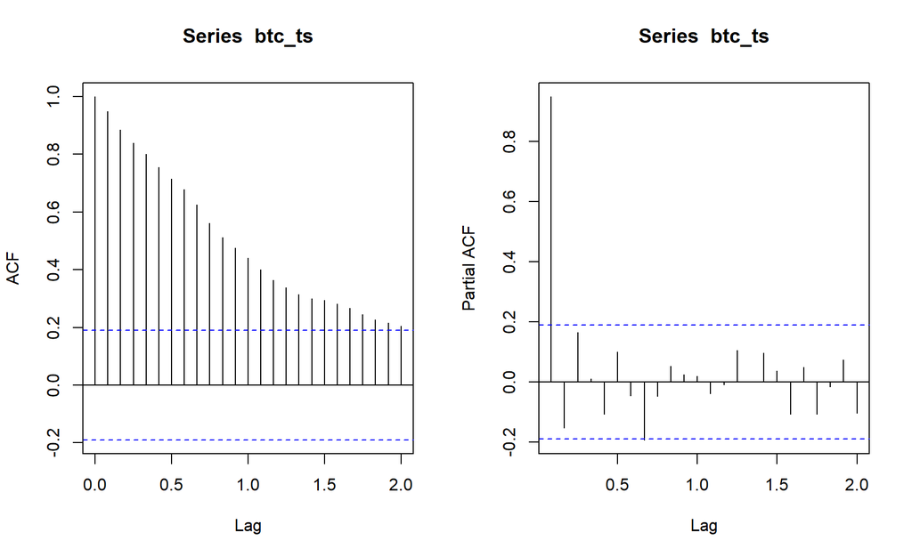

```r
# Load necessary libraries
library(lmtest)

# Convert the Bitcoin data frame to a time series object with frequency 12 (monthly data)
btc_ts <- ts(BitCoin$Price, start = c(2015, 1), frequency = 12)

# Check for and handle missing values
if (any(is.na(btc_ts))) {
  btc_ts <- na.approx(btc_ts)  # Linear interpolation to handle missing values
}
# ACF & PACF
par(mfrow=c(1,2))
acf(btc_ts, lag.max = 24)
pacf(btc_ts, lag.max = 24)
```

**ACF and PACF Explanation:** The ACF plot shows a slow decay of auto correlations, indicating non-stationarity and the need for differencing to achieve stationarity, common in financial time series. The PACF plot shows a significant spike at lag 1, suggesting the series may follow an AR(1) process, indicating that the AR term in the ARIMA model may be sufficient with a low order.

```r
library(tseries)
adf.test(btc_ts)

    Augmented Dickey-Fuller Test

data:  btc_ts
Dickey-Fuller = -2.5743, Lag order = 4, p-value = 0.3385
alternative hypothesis: stationary
```

**ADF Explanation:** The Augmented Dickey-Fuller test results for the Bitcoin time series (btc_ts) indicate non-stationarity (p-value = 0.3385), suggesting the need for differencing to achieve stationarity before fitting an ARIMA model.

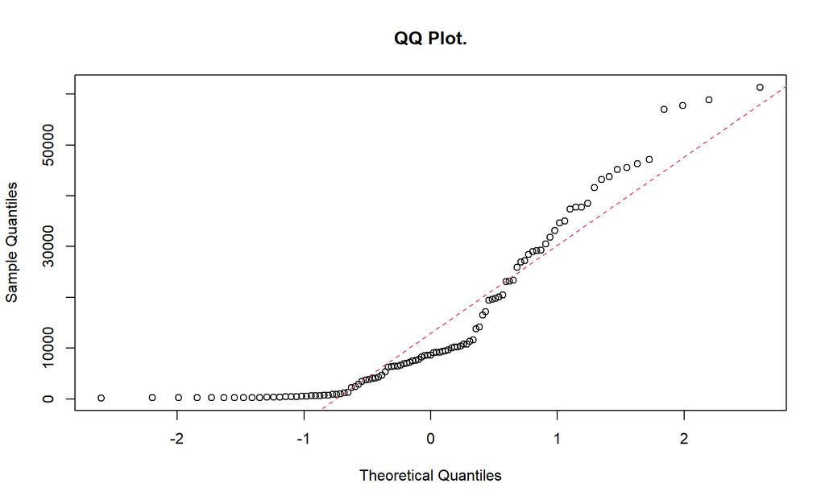

```r
qqnorm(y=btc_ts,main = "QQ Plot.")
qqline(y=btc_ts,col=2,lwd=1,lty=2)
```

**QQPlot Explanation of Bitcoin Time Series:** The QQ plot shows that the sample quantiles deviate significantly from the theoretical quantiles, especially in the tails, indicating that the Bitcoin time series data is not normally distributed. The heavy tails suggest the presence of extreme values or outliers. This non-normality needs to be addressed, possibly by transforming the data or using models that do not assume normality.

```r
sw <-  shapiro.test(btc_ts)
sw

    Shapiro-Wilk normality test

data:  btc_ts
W = 0.83358, p-value = 1.258e-09
```

**Shapiro-Wilk Test Explanation of Bitcoin Time Series:**

Since the p-value is very small (much less than the typical significance level of 0.05), we reject the null hypothesis that the data is normally distributed. This suggests that btc_ts does not follow a normal distribution.

### Differencing The Data for Stationarity

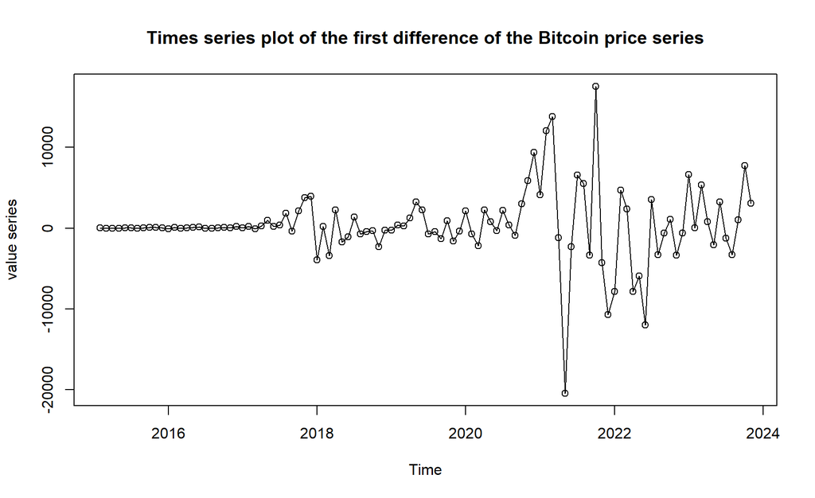

```r
#Differencing
stationary <- diff(btc_ts)
par(mfrow=c(1,1))
plot(stationary,type='o',ylab="value series", main="Times series plot of the first difference of the Bitcoin price series")
```

```r
adf.test(stationary)

    Augmented Dickey-Fuller Test

data:  stationary
Dickey-Fuller = -5.1599, Lag order = 4, p-value = 0.01
alternative hypothesis: stationary
```

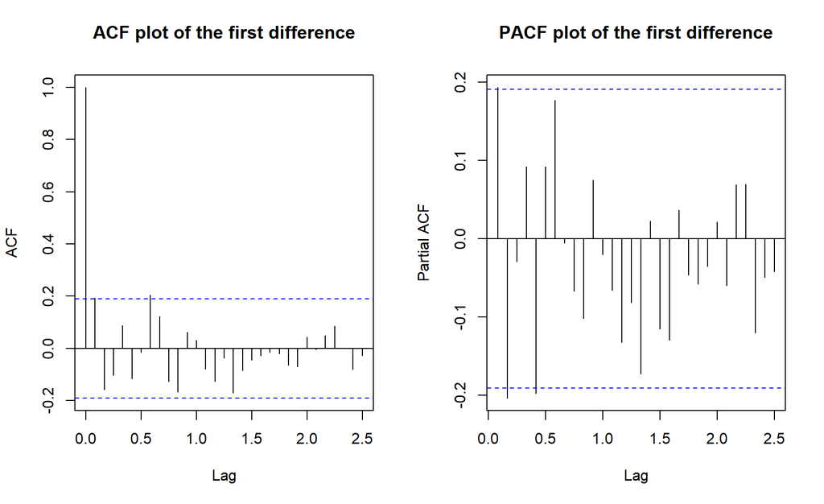

```r
#Model Selection
par(mfrow=c(1,2))
acf(stationary, main= "ACF plot of the first difference", lag.max = 30)
pacf(stationary, main= "PACF plot of the first difference", lag.max = 30)
```

The provided ACF (Autocorrelation Function) and PACF (Partial Autocorrelation Function) plots of the first difference of Bitcoin prices suggest that the time series is now stationary. In the ACF plot, the significant spike at lag 1 and the rapid decline thereafter indicate that the differencing has successfully removed the trend. In the PACF plot, the significant spike at lag 1 followed by smaller spikes suggests that an AR(1) model might be appropriate for the differenced series. Overall, these plots help in identifying the order of ARIMA models for time series forecasting.

```r
#EACF test
library(TSA)
eacf(stationary, ar.max=3, ma.max=3)
AR/MA
  0 1 2 3
0 o o o o
1 x x o o
2 o x o o
3 x o x o
```

**Based on the EACF, we select the ARIMA parameters of models (0,1,1), (0,1,2), (3,1,1)**

```r
#ARIMA(0,1,1)
model_011= arima(stationary,order=c(0,1,1))
coeftest(model_011)

z test of coefficients:

     Estimate Std. Error z value  Pr(>|z|)
ma1 -1.000000   0.028907 -34.594 < 2.2e-16 ***
---
Signif. codes:  0 '***' 0.001 '**' 0.01 '*' 0.05 '.' 0.1 ' ' 1
```

```r
#ARIMA(0,1,2)
model_012= arima(stationary,order=c(0,1,2))
coeftest(model_012)

z test of coefficients:

     Estimate Std. Error z value  Pr(>|z|)
ma1 -0.735344   0.099068 -7.4227 1.148e-13 ***
ma2 -0.264656   0.095704 -2.7654  0.005686 **
---
Signif. codes:  0 '***' 0.001 '**' 0.01 '*' 0.05 '.' 0.1 ' ' 1
```

```r
model_311= arima(stationary,order=c(3, 1, 1))
coeftest(model_311)

z test of coefficients:

     Estimate Std. Error  z value Pr(>|z|)
ar1  0.232756   0.097733   2.3816  0.01724 *
ar2 -0.190737   0.098518  -1.9361  0.05286 .
ar3 -0.021621   0.097960  -0.2207  0.82531
ma1 -0.999999   0.028776 -34.7507  < 2e-16 ***
---
Signif. codes:  0 '***' 0.001 '**' 0.01 '*' 0.05 '.' 0.1 ' ' 1
```

Coefficients with lower p-values are considered more significant. Based on the significance of coefficients, ARIMA(0,1,2) appears to be the most robust model, followed by ARIMA(0,1,1), and then ARIMA(3,1,1).

```r
# Extract AIC and BIC values
aic_values <- c(AIC(model_011), AIC(model_012), AIC(model_311))
bic_values <- c(BIC(model_011), BIC(model_012), BIC(model_311))

# Create a data frame
model_table <- data.frame(
  Model = c("model_011", "model_012", "model_311"),
  AIC = aic_values,
  BIC = bic_values
)

# Print the table
print(model_table)
      Model      AIC      BIC
1 model_011 2070.910 2076.218
2 model_012 2066.781 2074.743
3 model_311 2068.434 2081.703
```

#### Best Models Based on AIC and BIC:

**First Model:** Model 012 (ARIMA(0,1,2)) is the best choice according to both AIC and BIC, indicating a strong candidate for selection.

Therefore, while both AIC and BIC point to Model 012 as the best fit, Model 311 is also a reasonable choice, especially if predictive performance is a higher priority than model simplicity.

```r
model_012 = Arima(stationary, order = c(0, 1, 2))
model_311 = Arima(stationary, order = c(3, 1, 1))

a012 <- accuracy(model_012)
a311 <- accuracy(model_311)

df_models <- data.frame(
rbind(a012, a311)
)
colnames(df_models) <- c("ME", "RMSE", "MAE", "MPE", "MAPE", "MASE", "ACF1")
rownames(df_models) <- c("ARIMA(0,1,2)",  "ARIMA(3,1,1)")

kable(df_models, digits = 2, formats="html", row.names = TRUE) %>%
  kable_styling(full_width = F, font_size = 12, position = "center")
```

|  | ME | RMSE | MAE | MPE | MAPE | MASE | ACF1 |
| --- | --- | --- | --- | --- | --- | --- | --- |
| ARIMA(0,1,2) | 119.83 | 4312.32 | 2490.54 | -133.07 | 345.53 | 0.60 | -0.03 |
| ARIMA(3,1,1) | 130.74 | 4254.90 | 2423.61 | -137.00 | 345.50 | 0.59 | -0.01 |

**Findings From the Table:** The ARIMA(3,1,1) model has a slightly lower RMSE (4254.90 vs. 4312.32) and MAE (2423.61 vs. 2490.54) compared to the ARIMA(0,1,2) model, indicating better overall accuracy in terms of these metrics. The ACF1 values for both models are close to zero (-0.03 for ARIMA(0,1,2) and -0.01 for ARIMA(3,1,1)), suggesting minimal autocorrelation in the residuals, which is desirable. Despite these differences, both models exhibit high MAPE values, indicating substantial forecasting errors. Overall, ARIMA(3,1,1) performs slightly better in terms of error metrics, but both models have similar performance in terms of residual autocorrelation.

```r
res_012 <- rstandard(model_012)
res_311 <- rstandard(model_311)
```

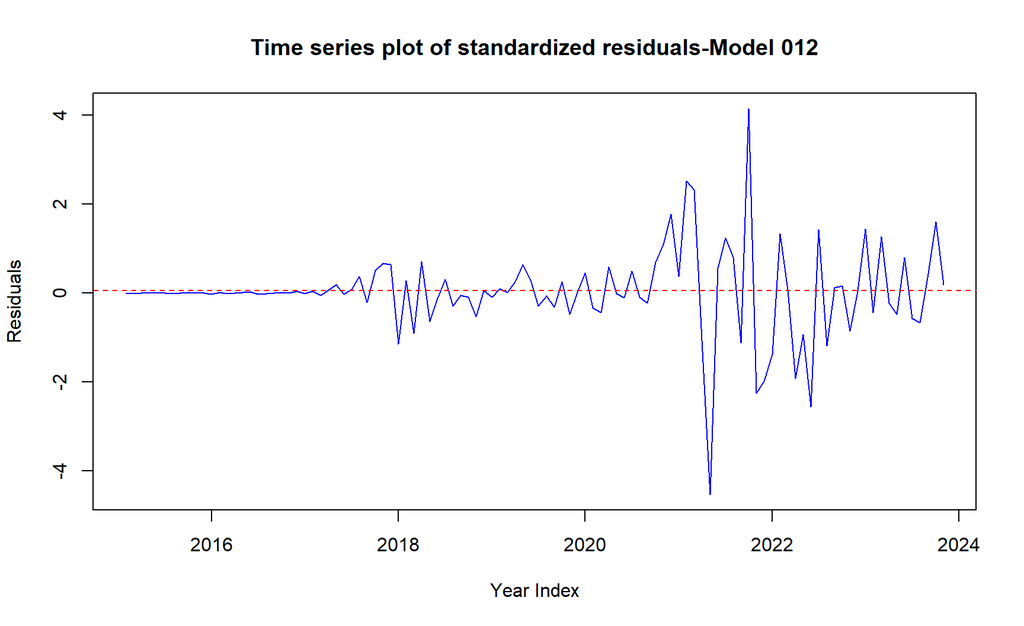

```r
#Model 012
par(mfrow = c(1, 1))

# Plot 1: Time series plot of standardized residuals
plot(res_012,
     xlab = "Year Index", ylab = "Residuals",
     main = "Time series plot of standardized residuals-Model 012")
lines(res_012, col = "blue")
abline(h = 0.05, col = "red", lty = 2)
```

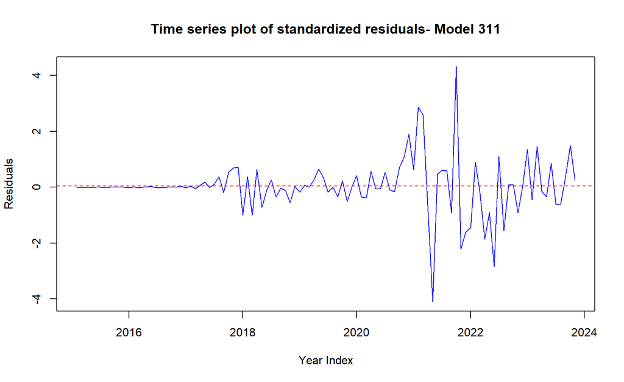

```r
#Model 311
par(mfrow = c(1, 1))

# Plot 1: Time series plot of standardized residuals
plot(res_311,
     xlab = "Year Index", ylab = "Residuals",
     main = "Time series plot of standardized residuals- Model 311")
lines(res_311, col = "blue")
abline(h = 0.05, col = "red", lty = 2)
```

**Both model 012 and 311 show stationarity.**

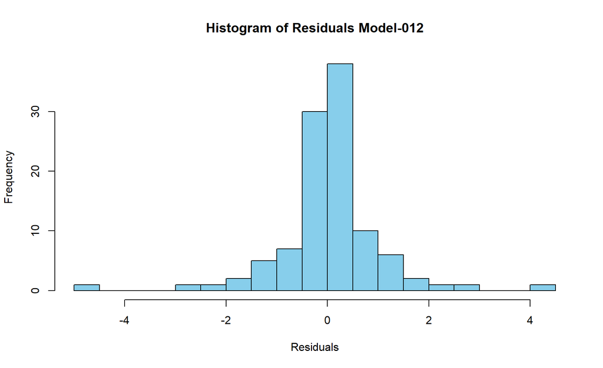

```r
#Histogram 012
hist(res_012,breaks=20, col="skyblue",
     xlab="Residuals",ylab="Frequency",
     main="Histogram of Residuals Model-012")
```

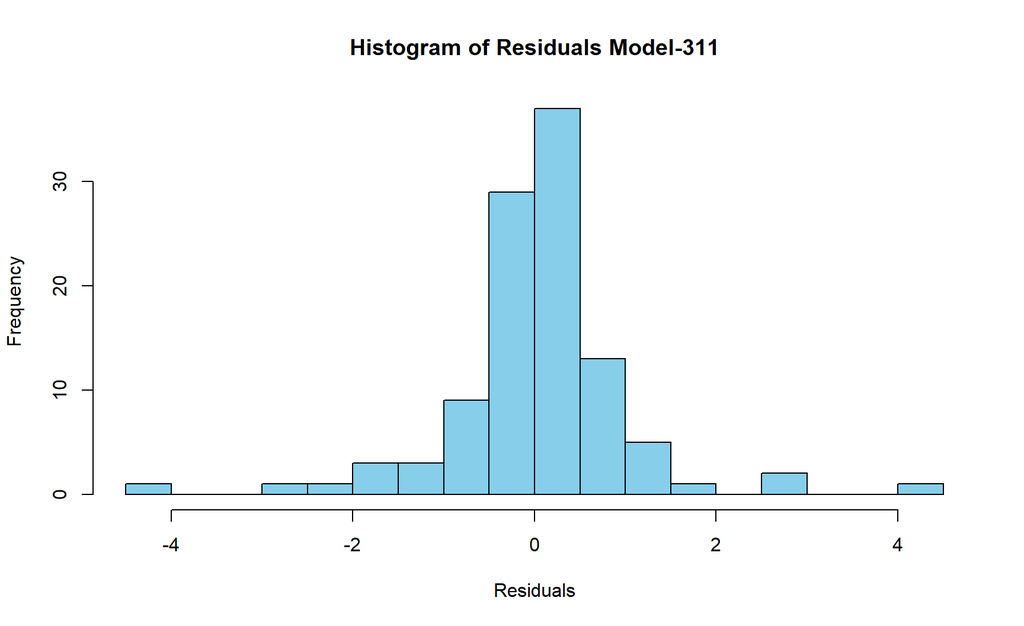

```r
#Histogram 311
hist(res_311,breaks=20, col="skyblue",
     xlab="Residuals",ylab="Frequency",
     main="Histogram of Residuals Model-311")
```

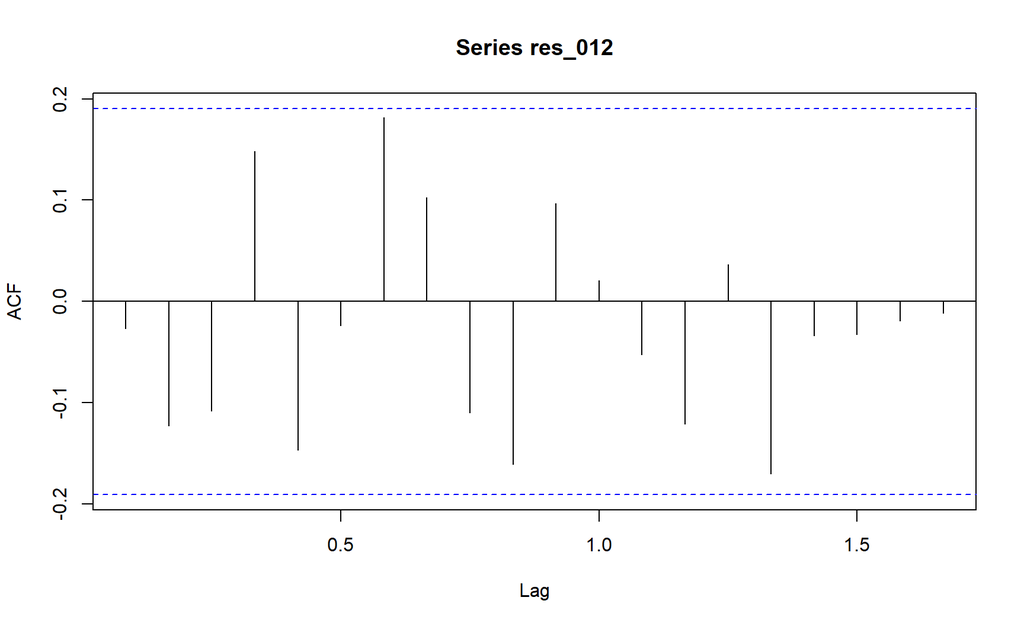

```r
# ACF & PACF of Residuals 012
acf_012 <- acf(res_012)
```

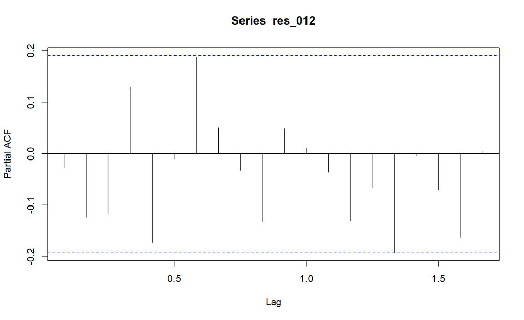

```r
pacf_012 <- pacf(res_012)
```

**ACF:** Both models have residuals with minimal autocorrelation, indicated by most spikes being within the 95% confidence bounds. Given the slightly lower residual variance and error metrics for ARIMA(3,1,1) compared to ARIMA(0,1,2), the ARIMA(3,1,1) model is considered slightly better.

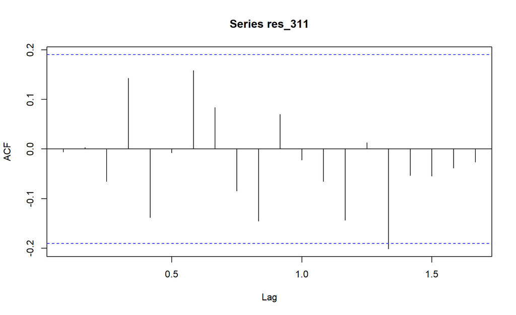

```r
# ACF & PACF of Residuals 311
acf_311 <- acf(res_311)
```

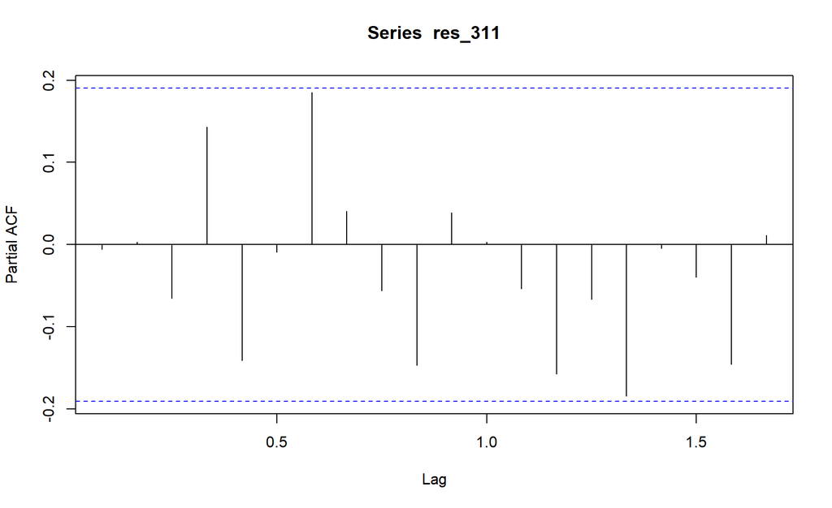

```r
pacf_311 <- pacf(res_311)
```

**PACF:** Both PACF plots indicate minimal partial autocorrelation, with most spikes within the confidence bounds for both models. Given the slightly better performance metrics and lower residual variance observed earlier, the ARIMA(3,1,1) model is considered slightly better overall.

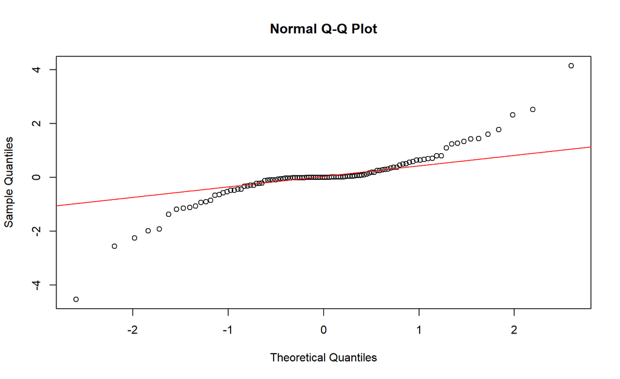

```r
#QQ Plot of Residuals 012
qqnorm(res_012)
qqline(res_012, col="red")
```

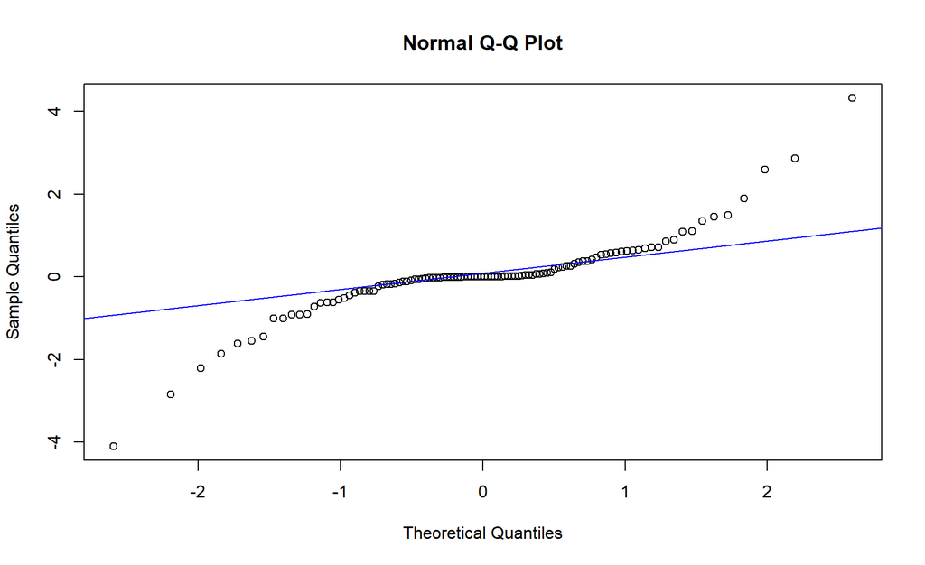

```r
#QQ Plot of Residuals 311
qqnorm(res_311)
qqline(res_311, col="blue")
```

```r
# Shapiro-Wilk Test on Residuals 012
print(shapiro.test(res_012))

    Shapiro-Wilk normality test

data:  res_012
W = 0.85275, p-value = 7.244e-09

# Shapiro-Wilk Test on Residuals 311
print(shapiro.test(res_311))

    Shapiro-Wilk normality test

data:  res_311
W = 0.84209, p-value = 2.889e-09
```

Both model’s residuals fail the Shapiro-Wilk normality test, indicating significant non-normality. The ARIMA(0,1,2) model has a slightly higher W statistic than the ARIMA(3,1,1) model, suggesting that its residuals are closer to normality.

Despite this, when considering previous analyses (lower residual variance and better fit metrics), the ARIMA(3,1,1) model is still considered slightly better overall.

## 4.5 Forecasting

```r
bitcoin_fit <- Arima(btc_ts,c(3,1,1))
forecasted_data <- forecast(bitcoin_fit,h=12)
kable(forecasted_data, digits = 2, formats="html", row.names = TRUE) %>%
  kable_styling(full_width = F, font_size = 12, position = "center")
```

|  | Point Forecast | Lo 80 | Hi 80 | Lo 95 | Hi 95 |
| --- | --- | --- | --- | --- | --- |
| Dec 2023 | 36845.30 | 31310.33 | 42380.28 | 28380.29 | 45310.31 |
| Jan 2024 | 35446.75 | 26687.77 | 44205.73 | 22051.04 | 48842.46 |
| Feb 2024 | 35412.19 | 24739.97 | 46084.40 | 19090.44 | 51733.93 |
| Mar 2024 | 35654.27 | 23806.65 | 47501.88 | 17534.91 | 53773.63 |
| Apr 2024 | 35858.11 | 22876.72 | 48839.50 | 16004.79 | 55711.43 |
| May 2024 | 35769.52 | 21705.48 | 49833.57 | 14260.42 | 57278.62 |
| Jun 2024 | 35750.07 | 20622.54 | 50877.59 | 12614.51 | 58885.62 |
| Jul 2024 | 35715.64 | 19632.13 | 51799.15 | 11118.03 | 60313.25 |
| Aug 2024 | 35751.02 | 18758.44 | 52743.61 | 9763.10 | 61738.94 |
| Sep 2024 | 35740.51 | 17898.02 | 53583.00 | 8452.77 | 63028.25 |
| Oct 2024 | 35751.93 | 17085.78 | 54418.09 | 7204.51 | 64299.36 |
| Nov 2024 | 35739.28 | 16290.63 | 55187.94 | 5995.13 | 65483.43 |

### 12-Month Forecast:

Forecasted values show a point forecast along with confidence intervals (80% and 95%). The plot of the forecasted values provides a visual representation of the expected Bitcoin price trends.

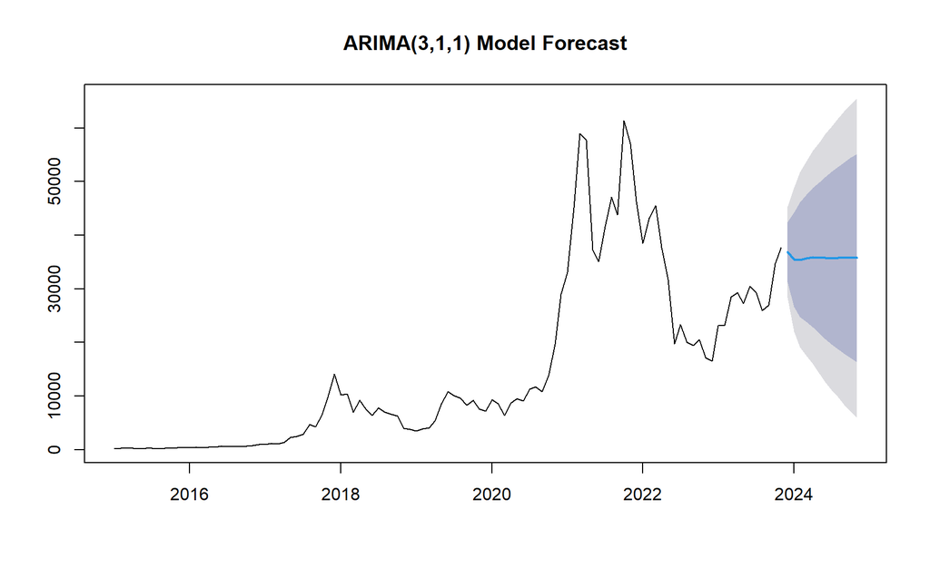

```r
# Plot the original data and the forecasted data
plot(forecasted_data, main = "ARIMA(3,1,1) Model Forecast")
```

## 4.6 Conclusion

### a. Performance Comparison:

#### Linear Regression:

**Pros:** Simple to implement and interpret.

**Cons:** Limited by linearity assumption, residuals show non-normality and autocorrelation.

#### Quadratic Regression:

**Pros:** Can model slight curvature in the trend.

**Cons:** The quadratic term was not significant, similar performance to linear regression.

#### ARIMA:

**Cons:** More complex to implement and interpret, requires careful model identification and validation.

### c. Final Remarks

*The ARIMA(3,1,1) model is appropriate* for forecasting Bitcoin prices as it accounts for trends and autocorrelation in the data. The forecasting results provide valuable insights for the next 12 months, helping in making informed decisions based on the expected price movements.